# Data Analysis Project (P2), NanoDegree program

### Fare

```python
# lets do summary statistics for the fare variable to see the general overview of how much passengers paid
titanic_df["Fare"].describe()
```

```
count    891.000000
mean      32.204208
std       49.693429
min        0.000000
25%        7.910400
50%       14.454200
75%       31.000000
max      512.329200
Name: Fare, dtype: float64
```

by having quick overview of the above table, we can see that the fare had a very high range with Std.Devn of 49.7. The maximum fare was 512 and min was 0.00( which suggest some passengers did not pay). Furthermore, more than 50% of passengers paid less than $15.

```python
# I will categorize the fare to be cheap or expensive based on the mean and try to investigate if higher fare meant
# better survival chance of passengers.
titanic_df["Fare"].mean()
```

```
32.2042079685746
```

```python
titanic_df['Ticket_Fare'] = titanic_df['Fare']
titanic_df['Ticket_Fare'].loc[titanic_df['Ticket_Fare'] > 32] = 'Expensive_Fare' # ticket_Fare > mean
titanic_df['Ticket_Fare'].loc[titanic_df['Ticket_Fare'] <= 32] = 'Cheap_Fare'    # ticket_Fare <= mean
titanic_df[0:10]
```

|  | PassengerId | Survived | Pclass | Name | Sex | Age | SibSp | Parch | Ticket | Fare | Cabin | Embarked | Family | Ticket_Fare |
| --- | --- | --- | --- | --- | --- | --- | --- | --- | --- | --- | --- | --- | --- | --- |
| 0 | 1 | 0 | 3 | Braund, Mr. Owen Harris | male | 22.0 | 1 | 0 | A/5 21171 | 7.2500 | NaN | S | With family | Cheap_Fare |
| 1 | 2 | 1 | 1 | Cumings, Mrs. John Bradley (Florence Briggs Th... | female | 38.0 | 1 | 0 | PC 17599 | 71.2833 | C85 | C | With family | Expensive_Fare |
| 2 | 3 | 1 | 3 | Heikkinen, Miss. Laina | female | 26.0 | 0 | 0 | STON/O2. 3101282 | 7.9250 | NaN | S | Alone | Cheap_Fare |
| 3 | 4 | 1 | 1 | Futrelle, Mrs. Jacques Heath (Lily May Peel) | female | 35.0 | 1 | 0 | 113803 | 53.1000 | C123 | S | With family | Expensive_Fare |
| 4 | 5 | 0 | 3 | Allen, Mr. William Henry | male | 35.0 | 0 | 0 | 373450 | 8.0500 | NaN | S | Alone | Cheap_Fare |
| 5 | 6 | 0 | 3 | Moran, Mr. James | male | 28.0 | 0 | 0 | 330877 | 8.4583 | NaN | Q | Alone | Cheap_Fare |
| 6 | 7 | 0 | 1 | McCarthy, Mr. Timothy J | male | 54.0 | 0 | 0 | 17463 | 51.8625 | E46 | S | Alone | Expensive_Fare |
| 7 | 8 | 0 | 3 | Palsson, Master. Gosta Leonard | male | 2.0 | 3 | 1 | 349909 | 21.0750 | NaN | S | With family | Cheap_Fare |
| 8 | 9 | 1 | 3 | Johnson, Mrs. Oscar W (Elisabeth Vilhelmina Berg) | female | 27.0 | 0 | 2 | 347742 | 11.1333 | NaN | S | With family | Cheap_Fare |
| 9 | 10 | 1 | 2 | Nasser, Mrs. Nicholas (Adele Achem) | female | 14.0 | 1 | 0 | 237736 | 30.0708 | NaN | C | With family | Cheap_Fare |

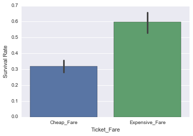

```python
ticket_fare=sns.barplot(x="Ticket_Fare", y="Survived",data=titanic_df)
ticket_fare.set(xlabel='Ticket_Fare', ylabel='Survival Rate')
plt.show()
```

The bar chart depicts that, passengers who paid higher fare had better survival rate than those who paid less. This might not be a good indicator as I created only 2 categories and some info may be hiden inside. But to some degree I believe that, the idea coincides with the general idea of current marine transportation fare, where first class passengers get better treatment

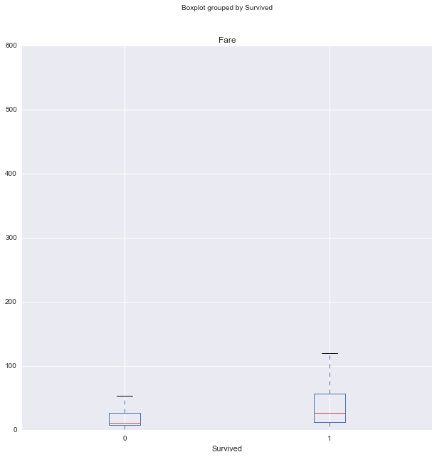

```python
titanic_df.boxplot(column="Fare",
                 by= "Survived",
                 figsize= (10,10))
```

## conclusion

### Summary of Findings

Our findings can be summerized in the following short ways:

[output not shown]

### Limitations

Our data (and our few variables) do not help us to investigate more and get an answer why survival was affected by one variable: for example our data indicates hihger survival rate for class 1 than class 2 or class 3, but it does not tell if it was merely due to luck (less number of passengers, its height from the water body, which may help passengers to stay on top of water till they got aid) or if class 1 was equiped with better equipments to survive the danger (number of lifeboats in that class etc). So we dont have concrete answer to why survival rate was different among different variables.

## citation

1. https://en.wikipedia.org/wiki/Age_of_majority
2. https://stanford.edu/~mwaskom/software/seaborn/tutorial/categorical.html
3. https://www.kaggle.com/c/titanic/details/getting-started-with-python-ii
4. https://www.youtube.com/watch?v=VavyFWb-r-8
5. http://stackoverflow.com/questions/17116814/pandas-how-do-i-split-text-in-a-column-into-multiple-rows
6. https://dato.com/learn/gallery/notebooks/who_survived_the_titanic.html